# DarkCovidNet_binary_classes

## COVID-19 X-ray images classification

#### Author: Yilin Xu

#### Date: Oct.6.2020

#### Introduction:

- " The novel coronavirus 2019 (COVID-19), which first appeared in Wuhan, China in December 2019, spread rapidly around the world and became a global pandemic. This resulted in a devastating effect on both daily lives, public health, and the global economy. It is critical to detect the positive cases as early as possible to prevent the further spread of this epidemic and to quickly treat infected patients. The need for auxiliary diagnostic tools has increased as there are no accurate automated toolkits available. Recent findings obtained using radiology imaging techniques suggest that such images contain salient information about the COVID-19 virus. Application of advanced artificial intelligence (AI) techniques coupled with radiological imaging can be helpful for the accurate detection of this disease, and can also be assistive to overcome the problem of a lack of specialized physicians in remote villages."
- This notebook is a replication of the DarkCovidNet model<sup>1</sup> to classify radiological images as indicative of either "COVID-19" or "No Finding" to assist in the diagnosis if COVID-19. This is an extension of the notebook published along with the paper in GitHub https://github.com/muhammedtalo/COVID-19/blob/master/DarkCovidNet%20%20for%20binary%20classes.ipynb. We use data available in the Chicagoland Pandemic Response Commons (CRPC) for this notebook.
1. Ozturk et. al. 2020. Automated detection of COVID-19 cases using deep neural networks with X-ray. Comput Biol Med. 2020 Jun; 121: 103792. (doi: 10.1016/j.compbiomed.2020.103792).

#### Data Source:

- open-COXRAY project in the CPRC contains X-ray images for COVID-19 patients imported from https://github.com/ieee8023/covid-chestxray-dataset. X-ray images for COVID-19 patients are queried and downloaded for image classification.
- open-ChestX-ray8 project in the CPRC contains X-ray images for individuals with a "No Finding" designation imported from https://github.com/muhammedtalo/COVID-19/tree/master/X-Ray%20Image%20DataSet/No_findings. X-ray images for "No Finding" individuals are queried and downloaded.

#### Set up notebook

```python
%reload_ext autoreload
%autoreload 2
%matplotlib inline
import warnings
warnings.filterwarnings('ignore')
```

The Vision module in fastai package contains the classification methods we will use. Uncomment to install python package.

```python
# !pip install gitpython
# !pip install gen3
# !pip install fastai==1.0.61 --user --no-use-pep517
from fastai.vision import *
import numpy as np
from pathlib import Path
import os
import peregrine as pg
from gen3.auth import Gen3AuthError
```

### DarkCovidNet for Binary classes

#### Query and download image data from Chicagoland Pandemic Data Commons for binary classes

Query GUIDs for image data classfied as "No Finding" and "COVID-19 Cases"

```python
# Query image object id and clinical note information
images_info = pg.get_images("open-ChestX-ray8")
```

```python
# Query image object id and clinical note for COVID-19 cases
covid_info = pg.get_observation_images("open-COXRAY")
```

Download image files for No Finding cases

```python
# Subset no finding rows
is_no_finding =  images_info['clinical_notes']=='No_findings'
no_findings = images_info[is_no_finding]
```

```python
# Create images/no_finding dir if not exist
os.makedirs('binary_images/no_finding', exist_ok=True)
os.chdir('binary_images/no_finding')
# Download image files
no_findings['GUID'].apply(lambda x: pg.download_object(x))
os.chdir('../../')
```

Download image files for COVID-19 cases

```python
# Create images/no_finding dir if not exist
os.makedirs('binary_images/covid19', exist_ok=True)
os.chdir('binary_images/covid19')
# Download image files
covid_info['GUID'].apply(lambda x: pg.download_object(x))
os.chdir('../../')
```

#### Load Image data as ImageDataBunch object

Declare path of image files which are organized in different folders representing distinct categories.

```python
path = Path('binary_images')
```

- All of the images are the 256 * 256 pixels and batch size is defined as 32
- The image data is normalized to have mean of 0 and a standard deviation of 1
- We randomly separate images to training and testing datasets in an 8:2 ratio with a random seed of 41

```python
np.random.seed(41)
data = ImageDataBunch.from_folder(path, train=".", valid_pct =0.2,
        ds_tfms=get_transforms(), size=(256,256), bs=32, num_workers=0).normalize()
```

Show image group names, group numbers, size of training images and size of testing image.

```python
data.classes, data.c, len(data.train_ds), len(data.valid_ds)
```

```
(['covid19', 'no_finding'], 2, 627, 156)
```

As previously mentioned the batch size is 32 and each image has 3 channels with 256 * 256 pixels.

```python
xb,yb = data.one_batch()
xb.shape,yb.shape
```

```
(torch.Size([32, 3, 256, 256]), torch.Size([32]))
```

Show a subset of normalized x-ray images (3 row * 3 column)

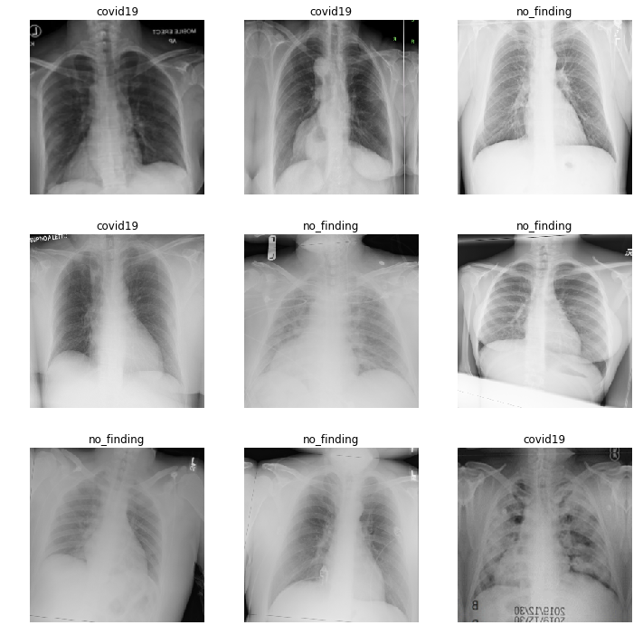

```python
data.show_batch(rows=3, figsize=(10,10))
```

#### Construct DarkCovidNet CNN for binary classes (modified Darknet model)

- Define one layer of the convolutional neural network using fastai and PyTorch
- Each layer has one convolution, one normalization, and one activation
- We use LeakyReLU with a negative slope of 0.1 as the activation function

ni: number of input (number of channels in the input image).

nf: number of filter.

size: kernel_size (size of the convolving kernel).

stride: skip number.

padding: amount of pixels adding to the input image.

```python
def conv_block(ni, nf, size=3, stride=1):
    for_pad = lambda s: s if s > 2 else 3
    return nn.Sequential(
        nn.Conv2d(ni, nf, kernel_size=size, stride=stride,
                  padding=(for_pad(size) - 1)//2, bias=False),
        nn.BatchNorm2d(nf),
        nn.LeakyReLU(negative_slope=0.1, inplace=True)
    )
```

Define triple convolution layers.

```python
def triple_conv(ni, nf):
    return nn.Sequential(
        conv_block(ni, nf),
        conv_block(nf, ni, size=1),
        conv_block(ni, nf)
    )
```

Define maxpooling with size of 2 and stride of 2 to extract most activated presence of a feature

```python
 def maxpooling():
    return nn.MaxPool2d(2, stride=2)
```

- Construct DarkCovidNet architecture with 17 convolution layers
- The number of filters are gradually increased (e.g., 8,16,32)

```python
model = nn.Sequential(
    conv_block(3, 8),
    maxpooling(),
    conv_block(8, 16),
    maxpooling(),
    triple_conv(16, 32),
    maxpooling(),
    triple_conv(32, 64),
    maxpooling(),
    triple_conv(64, 128),
    maxpooling(),
    triple_conv(128, 256),
    conv_block(256, 128, size=1),
    conv_block(128, 256),
    conv_layer(256, 2),
    Flatten(),
    nn.Linear(338, 2)
)
```

#### Train DarkCovidNet CNN

Use fastai.vision.learner to train a randomly initialized model. Our loss function, cross-entropy loss, or log loss, measures the performance of a classification model as a probability value between 0 and 1. Cross-entropy loss increases as the predicted probability diverges from the actual label.

```python
learn = Learner(data, model, loss_func = nn.CrossEntropyLoss(), metrics=accuracy)
```

DarkCovidNet CNN summary

```python
print(learn.summary())
```

```
Sequential
======================================================================
Layer (type)         Output Shape         Param #    Trainable
======================================================================
Conv2d               [8, 256, 256]        216        True
______________________________________________________________________
BatchNorm2d          [8, 256, 256]        16         True
______________________________________________________________________
LeakyReLU            [8, 256, 256]        0          False
______________________________________________________________________
MaxPool2d            [8, 128, 128]        0          False
______________________________________________________________________
Conv2d               [16, 128, 128]       1,152      True
______________________________________________________________________
BatchNorm2d          [16, 128, 128]       32         True
______________________________________________________________________
LeakyReLU            [16, 128, 128]       0          False
______________________________________________________________________
MaxPool2d            [16, 64, 64]         0          False
______________________________________________________________________
Conv2d               [32, 64, 64]         4,608      True
______________________________________________________________________
BatchNorm2d          [32, 64, 64]         64         True
______________________________________________________________________
LeakyReLU            [32, 64, 64]         0          False
______________________________________________________________________
Conv2d               [16, 66, 66]         512        True
______________________________________________________________________
BatchNorm2d          [16, 66, 66]         32         True
______________________________________________________________________
LeakyReLU            [16, 66, 66]         0          False
______________________________________________________________________
Conv2d               [32, 66, 66]         4,608      True
______________________________________________________________________
BatchNorm2d          [32, 66, 66]         64         True
______________________________________________________________________
LeakyReLU            [32, 66, 66]         0          False
______________________________________________________________________
MaxPool2d            [32, 33, 33]         0          False
______________________________________________________________________
```

[output cut: 74 more lines]

```
BatchNorm2d          [2, 13, 13]          4          True
______________________________________________________________________
Flatten              [338]                0          False
______________________________________________________________________
Linear               [2]                  678        True
______________________________________________________________________

Total params: 1,164,434
Total trainable params: 1,164,434
Total non-trainable params: 0
Optimized with 'torch.optim.adam.Adam', betas=(0.9, 0.99)
Using true weight decay as discussed in https://www.fast.ai/2018/07/02/adam-weight-decay/
Loss function : CrossEntropyLoss
======================================================================
Callbacks functions applied
```

Plot the learning rate vs loss to identify the maximum learning rate.

66.67% [4/6 02:34<01:17]

| epoch | train_loss | valid_loss | accuracy | time |
| --- | --- | --- | --- | --- |
| 0 | 0.814419 | #na# | 00:37 |  |
| 1 | 0.719343 | #na# | 00:39 |  |
| 2 | 0.596869 | #na# | 00:37 |  |
| 3 | 0.623248 | #na# | 00:39 |  |

73.68% [14/19 00:26<00:09 2.0523]

```
LR Finder is complete, type {learner_name}.recorder.plot() to see the graph.
```

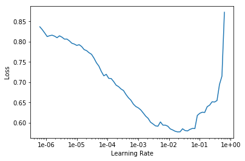

```python
learn.lr_find()
learn.recorder.plot()
```

When training Deep Learning models with Fastai it is recommended to use the fit_one_cycle() method, due to its better performance in speed and accuracy, over the fit() method. In short, fit_one_cycle() is Fastai’s implementation of Leslie Smith’s 1cycle policy. Here we set Epoch = 100, maximum learning rate = 3e-3.

```python
epoch = 100
learn.fit_one_cycle(epoch, max_lr=3e-3)
```

| epoch | train_loss | valid_loss | accuracy | time |
| --- | --- | --- | --- | --- |
| 0 | 0.554160 | 0.710313 | 0.442308 | 00:43 |
| 1 | 0.485524 | 0.530154 | 0.737179 | 00:46 |
| 2 | 0.422621 | 0.350437 | 0.833333 | 00:44 |
| 3 | 0.378370 | 0.456366 | 0.826923 | 00:47 |
| 4 | 0.358861 | 0.232083 | 0.891026 | 00:44 |
| 5 | 0.331838 | 0.168190 | 0.935897 | 00:43 |
| 6 | 0.311099 | 0.385961 | 0.826923 | 00:46 |
| 7 | 0.286214 | 0.366794 | 0.788462 | 00:43 |
| 8 | 0.288428 | 0.265128 | 0.891026 | 00:44 |
| 9 | 0.292437 | 0.322470 | 0.846154 | 00:44 |
| 10 | 0.266850 | 0.620836 | 0.737179 | 00:44 |
| 11 | 0.272421 | 0.489503 | 0.858974 | 00:44 |
| 12 | 0.285740 | 0.972733 | 0.750000 | 00:47 |
| 13 | 0.278896 | 0.701510 | 0.711538 | 00:44 |
| 14 | 0.274850 | 0.266661 | 0.903846 | 00:45 |
| 15 | 0.272627 | 0.238338 | 0.910256 | 00:46 |
| 16 | 0.284492 | 0.253409 | 0.891026 | 00:45 |
| 17 | 0.291742 | 0.588685 | 0.724359 | 00:46 |
| 18 | 0.289112 | 0.202399 | 0.942308 | 00:43 |
| 19 | 0.286018 | 3.436783 | 0.455128 | 00:47 |
| 20 | 0.303092 | 0.644175 | 0.826923 | 00:43 |
| 21 | 0.297573 | 0.353685 | 0.839744 | 00:44 |
| 22 | 0.279161 | 0.569287 | 0.820513 | 00:46 |
| 23 | 0.266483 | 1.134772 | 0.673077 | 00:43 |
| 24 | 0.266380 | 0.345141 | 0.910256 | 00:45 |
| 25 | 0.284115 | 1.566142 | 0.692308 | 00:44 |
| 26 | 0.290917 | 0.382456 | 0.871795 | 00:46 |
| 27 | 0.291906 | 0.393980 | 0.884615 | 00:44 |
| 28 | 0.281245 | 0.665706 | 0.705128 | 00:42 |
| 29 | 0.266971 | 0.577858 | 0.743590 | 00:46 |

[output cut: 70 more lines]

#### Plot the Epoch and loss for both training data and validation data

The loss values decrease as the Epoch increases for both the training dataset and the validation dataset. When epoch exceeds 90, the loss values and accuracy values are stable. 100 Epoch is a good amount of times fitting the data to the model.

```python
# Extract loss and accuracy values
segment = math.floor(len(data.train_ds)/32)
epoch_list = list(range(1,epoch+1))
index = [x*segment-1 for x in epoch_list]
train_loss = [float(learn.recorder.losses[i]) for i in index]
val_loss = learn.recorder.val_losses
accuracy = [float(x[0]) for x in learn.recorder.metrics]
```

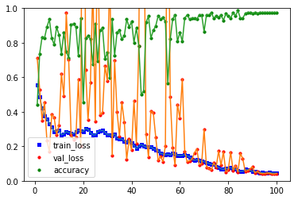

```python
# Plot loss and accuracy values
fig = plt.figure()
ax1 = fig.add_subplot(111)
ax1.set_ylim([0, 1])
ax1.plot(epoch_list,train_loss,zorder=1)
ax1.scatter(epoch_list, train_loss, s=10, c='b', marker="s", label='train_loss')
ax1.plot(epoch_list,val_loss,zorder=1)
ax1.scatter(epoch_list,val_loss, s=10, c='r', marker="o", label='val_loss')
ax1.plot(epoch_list,accuracy,zorder=1)
ax1.scatter(epoch_list,accuracy, s=10, c='g', marker="o", label='accuracy')
plt.legend(loc='lower left');
plt.show()
```

#### Evaluate precision, recall f1 score for validation dataset and plot confusion matrix

```python
# Extract probability and labels for validation datset
probs,targets = learn.get_preds(ds_type=DatasetType.Valid)
# Prediction
probs = np.argmax(probs, axis=1)
```

```python
# Calculate accuracy and plot the confusion matrix and classification report
correct = 0
for idx, pred in enumerate(probs):
    if pred == targets[idx]:
        correct += 1
accuracy = correct / len(probs)
print("Accuracy:")
print(len(probs), correct, accuracy)
print("********")

from sklearn.metrics import confusion_matrix
np.set_printoptions(threshold=np.inf)
cm1 = confusion_matrix(targets, probs)
print("Confusion Matrix:")
print(cm1)
print("********")

from sklearn.metrics import classification_report
y_true1 = targets
y_pred1 = probs
target_names = ['Covid-19', 'No_findings']
print("Classification Report:")
print(classification_report(y_true1, y_pred1, target_names=target_names))
```

```
Accuracy:
156 152 0.9743589743589743
********
Confusion Matrix:
[[66  3]
 [ 1 86]]
********
Classification Report:
              precision    recall  f1-score   support

    Covid-19       0.99      0.96      0.97        69
 No_findings       0.97      0.99      0.98        87

    accuracy                           0.97       156
   macro avg       0.98      0.97      0.97       156
weighted avg       0.97      0.97      0.97       156
```

- The accuracy of the model predicting COVID-19 cases with validation dataset is (66+86)/(66+3+1+86)=97%.
- Among 69 COVID-19 images, 66 cases were predicted correctly. The recall rate for COVID-19 is 66/69 =96%.
- Among 67 predicted COVID-19 cases, 66 cases are COVID-19. The precision rate for COVID-19 is 66/67=99%.
- F1 score for COVID-19 is (96%+99%)/2 = 97%.
- Among 87 No Finding cases, 86 cases were predicted correctly. The recall rate for "No Finding" is 86/87=99%.
- Among 89 predicted No Finding cases, 86 cases are "No finding". The precision rate for "No Finding" is 86/89=97%
- F1 score for "No Finding" is (99%+97%)/2=98%

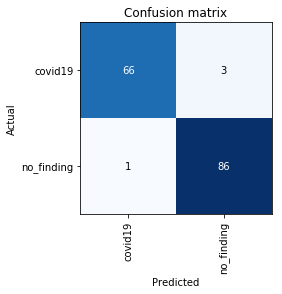

```python
# Plot confusion matrix
interp = ClassificationInterpretation.from_learner(learn)
cm_fig = interp.plot_confusion_matrix(return_fig=True)
ax = cm_fig.gca()
ax.set_ylim(interp.data.c - .5, - .5);
```

- Positive cases are labeled as "COVID-19" and negative cases are labeled as "No Finding".
- The confusion matrix shows true positive case numbers are 66, and true negative case numbers are 86.
- False positive case numbers are 1 and false negative case numbers are 3.

#### Conclusion

We applied the DarkCovidNet model to classify x-ray images for No Finding and COVID-19 cases. After training the model with over 100 epochs, the losses for the training dataset and validation dataset is stable and the accuracy is 97.4%.

The confusion matrix showed that the model could distinguish the Covid-19 cases from No findings well. Of the 69 COVID-19 cases in the validation dataset, 66 were predicted as COVID-19 cases. For the 87 “No finding” cases, only one case was incorrectly predicted as a COVID-19 case. The precision for predicting COVID-19 from No finding is high (99%) with a recall rate of 96%. This notebook demonstrates the potential predictive power of deep neural networks for diagnosis of COVID-19.